# AS3-1: 數位偵探

第 9 組

2019-03-12 11:44:21

犯罪是一個國際關注的問題，但它在不同的國家以不同的方式記錄和處理。 在美國，聯邦調查局（FBI）記錄了暴力犯罪和財產犯罪。 此外，每個城市都記錄了犯罪行為，一些城市發布了有關犯罪率的數據。 伊利諾伊州芝加哥市從2001年開始在線發布犯罪數據。

芝加哥是美國人口第三多的城市，人口超過270萬。在這個作業裡面，我們將關注一種特定類型的財產犯罪，稱為「汽車盜竊」，我們將使用R中的一些基本數據分析來了解芝加哥的汽車盜竊紀錄。請載入文件“data/mvtWeek1.csv”：以下是各欄位的描述：

- `ID`: a unique identifier for each observation
- `Date`: the date the crime occurred
- `LocationDescription`: the location where the crime occurred
- `Arrest`: whether or not an arrest was made for the crime (TRUE if an arrest was made, and FALSE if an arrest was not made)
- `Domestic`: whether or not the crime was a domestic crime, meaning that it was committed against a family member (TRUE if it was domestic, and FALSE if it was not domestic)
- `Beat`: the area, or “beat” in which the crime occurred. This is the smallest regional division defined by the Chicago police department.
- `District`: the police district in which the crime occured. Each district is composed of many beats, and are defined by the Chicago Police Department.
- `CommunityArea`: the community area in which the crime occurred. Since the 1920s, Chicago has been divided into what are called “community areas”, of which there are now 77. The community areas were devised in an attempt to create socially homogeneous regions.
- `Year`: the year in which the crime occurred.
- `Latitude`: the latitude of the location at which the crime occurred.
- `Longitude`: the longitude of the location at which the crime occurred.

### Section-1 Loading the Data

【1.1】How many rows of data (observations) are in this dataset?

```r
D = read.csv("data/mvtWeek1.csv")
nrow(D) ### 191641
```

```
[1] 191641
```

檢查各欄位的資料格式

```r
str(D)
```

```
'data.frame':   191641 obs. of  11 variables:
 $ ID                 : int  8951354 8951141 8952745 8952223 8951608 8950793 8950760 8951611 8951802 8950706 ...
 $ Date               : Factor w/ 131680 levels "1/1/01 0:01",..: 42824 42823 42823 42823 42822 42821 42820 42819 42817 42816 ...
 $ LocationDescription: Factor w/ 78 levels "ABANDONED BUILDING",..: 72 72 62 72 72 72 72 72 72 72 ...
 $ Arrest             : logi  FALSE FALSE FALSE FALSE FALSE TRUE ...
 $ Domestic           : logi  FALSE FALSE FALSE FALSE FALSE FALSE ...
 $ Beat               : int  623 1213 1622 724 211 2521 423 231 1021 1215 ...
 $ District           : int  6 12 16 7 2 25 4 2 10 12 ...
 $ CommunityArea      : int  69 24 11 67 35 19 48 40 29 24 ...
 $ Year               : int  2012 2012 2012 2012 2012 2012 2012 2012 2012 2012 ...
 $ Latitude           : num  41.8 41.9 42 41.8 41.8 ...
 $ Longitude          : num  -87.6 -87.7 -87.8 -87.7 -87.6 ...
```

類別(Factor) versus 字串(Character)

【1.2】How many variables are in this dataset?

```r
#11
ncol(D)
```

```
[1] 11
```

【1.3】Using the “max” function, what is the maximum value of the variable “ID”?

```r
#9181151
max(D$ID)
```

```
[1] 9181151
```

【1.4】 What is the minimum value of the variable “Beat”?

```r
#111
min(D$Beat)
```

```
[1] 111
```

【1.5】 How many observations have value TRUE in the Arrest variable (this is the number of crimes for which an arrest was made)?

```r
#15536
sum(D$Arrest == "TRUE")
```

```
[1] 15536
```

【1.6】 How many observations have a LocationDescription value of ALLEY?

```r
#2308
sum(D$LocationDescription == "ALLEY")
```

```
[1] 2308
```

### Section-2 Understanding Dates in R

【2.1】 In what format are the entries in the variable Date?

- Month/Day/Year Hour:Minute
- Day/Month/Year Hour:Minute
- Hour:Minute Month/Day/Year
- Hour:Minute Day/Month/Year

```r
#Month/Day/Year Hour:Minute
```

【2.2】 What is the month and year of the median date in our dataset?

```r
#2006年5月
ts = as.POSIXct(D$Date, format="%m/%d/%y %H:%M")
median(ts)
```

```
[1] "2006-05-21 12:30:00 CST"
```

【2.3】 In which month did the fewest motor vehicle thefts occur?

```r
### 2月
table(format(ts, '%m')) %>% sort()
```

```
   02    04    03    06    05    01    09    11    12    08    07    10
13511 15280 15758 16002 16035 16047 16060 16063 16426 16572 16801 17086
```

【2.4】 On which weekday did the most motor vehicle thefts occur?

```r
### 星期五
table(format(ts, '%w')) %>% sort(decreasing = TRUE)
```

```
    5     3     1     4     6     2     0
29284 27416 27397 27319 27118 26791 26316
```

【2.5】 Which month has the largest number of motor vehicle thefts for which an arrest was made?

```r
### 1月
table(format(ts[D$Arrest], '%m'))
```

```
  01   02   03   04   05   06   07   08   09   10   11   12
1435 1238 1298 1252 1187 1230 1324 1329 1248 1342 1256 1397
```

### Section-3 Visualizing Crime Trends

【3.1】 (a) In general, does it look like crime increases or decreases from 2002 - 2012? (b) In general, does it look like crime increases or decreases from 2005 - 2008? (c) In general, does it look like crime increases or decreases from 2009 - 2011?

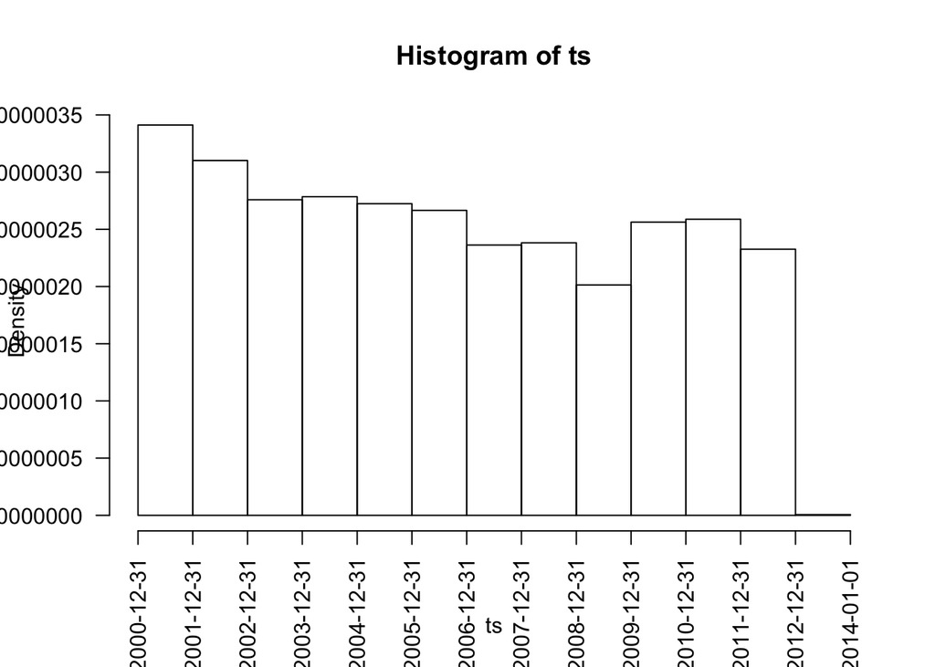

```r
#(a) 2002-2012 : decrease
#(b) 2005-2008 : decrease
#(c) 2009-2011 : increase
hist(ts, 'year', las=2)
```

【3.2】 Does it look like there were more crimes for which arrests were made in the first half of the time period or the second half of the time period?

```r
#the first half of the time period
table(ts > as.POSIXct("2007/01/01"))
```

```
 FALSE   TRUE
105523  86118
```

【3.3】 For what proportion of motor vehicle thefts in 2001 was an arrest made?

```r
#0.10412
table(D$Arrest, format(ts, '%Y')) %>% prop.table(2)
```

```
           2001    2002    2003    2004    2005    2006    2007    2008    2009    2010
  FALSE 0.89588 0.88722 0.89206 0.89960 0.90730 0.91912 0.91513 0.92939 0.93096 0.95477
  TRUE  0.10412 0.11278 0.10794 0.10040 0.09270 0.08088 0.08487 0.07061 0.06904 0.04523

           2011    2012
  FALSE 0.96003 0.96097
  TRUE  0.03997 0.03903
```

【3.4】 For what proportion of motor vehicle thefts in 2007 was an arrest made?

```r
#0.08487
```

【3.5】 For what proportion of motor vehicle thefts in 2012 was an arrest made?

```r
#0.03903
```

### Section-4 Popular Locations

【4.1】 Which locations are the top five locations for motor vehicle thefts, excluding the “Other” category? You should select 5 of the following options.

```r
#Street, Parking lot/garage, Alley, Gas station, Driveway - residential
Top5 = table(D$LocationDescription) %>% sort %>% tail(6)
Top5
```

```
        DRIVEWAY - RESIDENTIAL                    GAS STATION
                          1675                           2111
                         ALLEY                          OTHER
                          2308                           4573
PARKING LOT/GARAGE(NON.RESID.)                         STREET
                         14852                         156564
```

【4.2】 How many observations are in Top5?

```r
#177510
sum(Top5[-4])
```

```
[1] 177510
```

【4.3】 One of the locations has a much higher arrest rate than the other locations. Which is it?

```r
#Gas station
topName = names(table(D$LocationDescription) %>% sort %>% tail(6))[-4]
topName
```

```
[1] "DRIVEWAY - RESIDENTIAL"         "GAS STATION"
[3] "ALLEY"                          "PARKING LOT/GARAGE(NON.RESID.)"
[5] "STREET"
```

```r
TOP5 = subset(D, LocationDescription %in% topName)
tapply(TOP5$Arrest, TOP5$LocationDescription, mean) %>% sort
```

```
                        STREET         DRIVEWAY - RESIDENTIAL
                       0.07406                        0.07881
                         ALLEY PARKING LOT/GARAGE(NON.RESID.)
                       0.10789                        0.10793
                   GAS STATION
                       0.20796
```

【4.4】 On which day of the week do the most motor vehicle thefts at gas stations happen?

```r
#星期六
ts[D$LocationDescription == "GAS STATION"] %>% format("%w") %>% table %>% sort
```

```
.
  2   3   1   4   5   0   6
270 273 280 282 332 336 338
```

【4.5】 On which day of the week do the fewest motor vehicle thefts in residential driveways happen?

```r
#星期六
ts[D$LocationDescription == "DRIVEWAY - RESIDENTIAL"] %>% format("%w") %>% table %>% sort
```

```
.
  6   0   3   2   1   5   4
202 221 234 243 255 257 263
```